# Rmarkdown: Gapminder

Tim Triche, Jr.

# What `knitr` output looks like

It takes a moment to load the Rstudio plumbing for the [Software Carpentries knitr lesson](https://swcarpentry.github.io/r-novice-gapminder/14-knitr-markdown.html), so here’s an example of what you can do with these tools, and why you might want to learn how to use them.

You don’t have to host your own Rmarkdown documents; in fact, Rstudio has a lovely option where you can publish your Rmarkdown or Quarto documents directly to [rpubs.com](https://rpubs.com/ttriche/1011627). (Note: the linked markdown document was a quickie and contains a number of Worst Practices…)

Depending on how fast webR loads, we may even have time to play with markdown from within this markdown document (press the play button to execute the code):

```
library("rmarkdown")

markdown <- "
A list
* Dataset: the Mountain of the Whau Tree
* μ(elevation) = `mean(volcano)`m
* σ(elevation) = `sd(volcano)`m
"

tmp_file <- tempfile(tmpdir=".")
cat(markdown, file=tmp_file)
output <- suppressWarnings(render(tmp_file))
cat(output)
```

The above-described dataset is `volcano`, included with base R. You can generate a plot of it below if you’d like to see it:

```
filled.contour(volcano, main="Topography of Maunga Whau volcano, Aotearoa")
```

Full disclosure: this particular document is also a sandbox for me (Tim) to experiment with [webR](https://docs.r-wasm.org/webr/latest/) and dynamic rendering, for example using knitr to make reveal.js slides. Moving right along…

## A bit of background

The Gapminder dataset you’ve been using is from a TED talk by Hans Rosling, which you can view [here](https://www.youtube.com/watch?v=hVimVzgtD6w) if you like. The Roslings compiled actuarial records of life expectancy, income, and population size for countries around the world over many years. Hans died in 2017, but the impact of his work lives on, partly because the [Gapminder foundation](https://www.gapminder.org/about/about-gapminder/history/) helps keep the data and tools from the talk available and usable.

You too can become immortal in this way. The first step is to make your data and analyses reproducible, so that other people can understand and build upon them. Let’s use Rosling’s data to motivate a few examples. If you want to peek at the [markdown document itself](https://github.com/trichelab/trichelab.github.io/blob/gh-pages/webR/gapminder/Gapminder.qmd), please do!

## The gapminder data in R

An excerpt of the data from Rosling’s talk is available in R via the [`gapminder`](https://cran.r-project.org/package=gapminder) package, which can be installed from CRAN via `install.packages("gapminder")`. We can check which version was installed:

```
install.packages("gapminder")
library("gapminder")
paste("gapminder", packageVersion("gapminder"))
```

## A quick look

Let’s take a quick look at the `gapminder` data itself. If you type the name of a data object into R, you will (almost always) get a glimpse of the data:

```r
library("gapminder")
gapminder
```

```
## # A tibble: 1,704 × 6
##    country     continent  year lifeExp      pop gdpPercap
##    <fct>       <fct>     <int>   <dbl>    <int>     <dbl>
##  1 Afghanistan Asia       1952    28.8  8425333      779.
##  2 Afghanistan Asia       1957    30.3  9240934      821.
##  3 Afghanistan Asia       1962    32.0 10267083      853.
##  4 Afghanistan Asia       1967    34.0 11537966      836.
##  5 Afghanistan Asia       1972    36.1 13079460      740.
##  6 Afghanistan Asia       1977    38.4 14880372      786.
##  7 Afghanistan Asia       1982    39.9 12881816      978.
##  8 Afghanistan Asia       1987    40.8 13867957      852.
##  9 Afghanistan Asia       1992    41.7 16317921      649.
## 10 Afghanistan Asia       1997    41.8 22227415      635.
## # ℹ 1,694 more rows
```

This isn’t necessarily an ideal way to inspect a dataset. The `head` and `tail` functions in R can be helpful when a dataset is too big to digest in one shot. What happens when you call these functions on the `gapminder` dataset?

```
library("gapminder")
head(gapminder)
tail(gapminder)
```

## Plotting with ggplot2

Earlier in the workshop, you plotted some of the gapminder data with `ggplot2`:

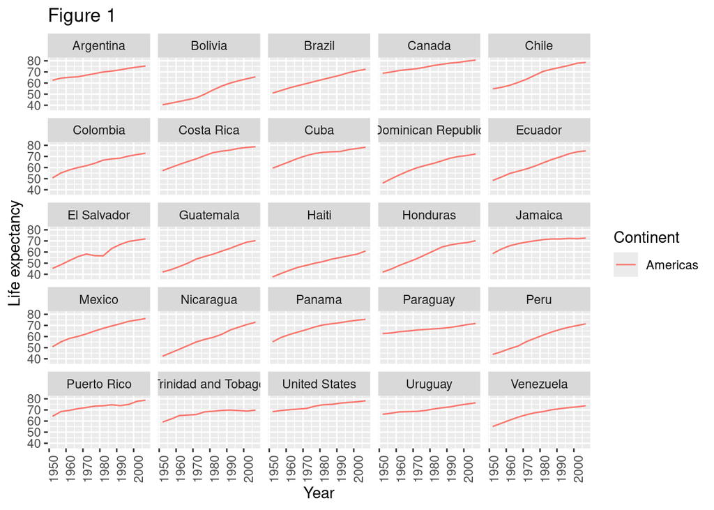

```r
library("gapminder")
americas <- gapminder[gapminder$continent == "Americas",]

library("ggplot2")
ggplot(data = americas,
       mapping = aes(x = year,
                     y = lifeExp,
                     color = continent)) +
  geom_line() +
  facet_wrap( ~ country) +
  labs(
    x = "Year",              # x axis title
    y = "Life expectancy",   # y axis title
    title = "Figure 1",      # main title of figure
    color = "Continent"      # title of legend
  ) +
  theme(axis.text.x = element_text(angle = 90, hjust = 1))
```

However, if you have seen Rosling’s talk, you may recall a particular style of plot (the “bubble plot”) used to great impact. Can we recreate that plot?

## A bubble plot

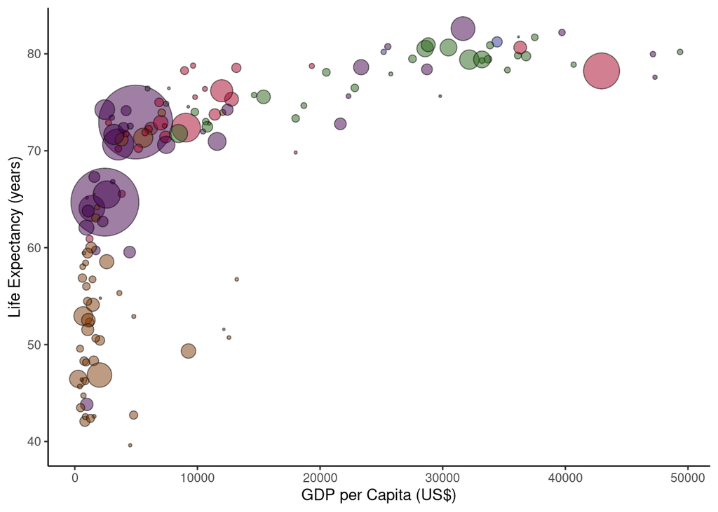

```r
library("gapminder")
library("ggplot2")
ggplot(subset(gapminder,
              year == "2007"),
       aes(x = gdpPercap,
           y = lifeExp,
           size = pop,
           fill = continent)) +
  geom_point(alpha=0.5, shape=21, color="black") +
  scale_size(range = c(.1, 24), name="Population (M)") +
  scale_fill_manual(values = continent_colors) +
  labs(y = "Life Expectancy (years)",
       x = "GDP per Capita (US$)") +
  guides(size = "none", fill = "none") +
  theme_classic()
```

### Challenge

Suppose you wanted to look at a different year’s worth of data (say, 1952), or a specific continent (for example, Asia). Can you modify the code so that it plots the data *you* want it to plot? Can you add a title in `labs()` and restore the `guides()` legend for `fill`, as well?

```
library("gapminder")
library("ggplot2")

ggplot(subset(gapminder,
              year == "2007"),
       aes(x = gdpPercap,
           y = lifeExp,
           size = pop,
           fill = continent)) +
  geom_point(alpha=0.5, shape=21, color="black") +
  scale_size(range = c(.1, 24), name="Population (M)") +
  scale_fill_manual(values = continent_colors) +
  labs(y = "Life Expectancy (years)",
       x = "GDP per Capita (US$)") +
  guides(size = "none", fill = "none") +
  theme_classic()
```